# Ordinal Data with Hierarchical Model

Langyan Zang

03 August, 2022

## Ordinal Data Analysis

The data in ratings_data.csv represent ratings on the desire to eat a food from a Likert scale (“Strong No”, “No”, “Neutral”, “Yes”, “Strong Yes”). These categorical responses are recorded as the numbers -2:2 in the data file. Once again there are groups of participants (A and B). Each individual rated 60 different foods in terms of the desire to eat on the Likert scale above, as well as two different attributes (x1 and x2) of the foods on a visual analog scale. We will assume that these visual analog ratings are continuous and censored by the endpoints of the scale. All participants saw the same 60 foods.

> *Analysis Design:* Test whether Group A and Group B differ in terms of how x1 and x2 influence their members’ desire to eat the snack food items according to the formula, $Rating \sim B_0 + B_1*x_1 + B_2*x_2 + \varepsilon$, using a hierarchical linear regression model (i.e. treating the scale as metric) and an hierarchical ordinal regression model. Both models should allow for different beta parameters for each participant under general normal distributions for each of the two groups. The group-level distributions should be separate and not inform one another.

### Histogram for both groups

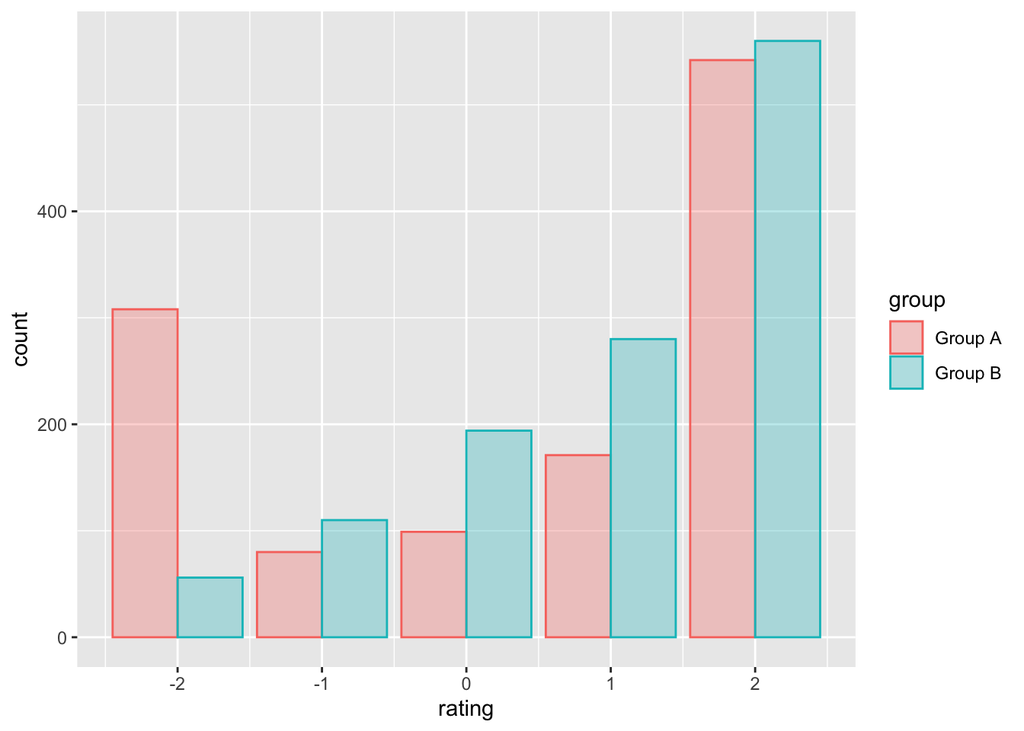

```r
data <- read.csv("data/ratings_data.csv",stringsAsFactors = FALSE)
# prepare data.frame for plot
df_plot <- data.frame(
    rating=c(data$Rating[which(data$Group=="A")],data$Rating[which(data$Group=="B")]),
    group=rep(c("Group A", "Group B"), each=length(data$Rating[which(data$Group=="A")]) )
    )
ggplot(df_plot, aes(x=rating, color=group, fill=group)) + geom_bar(alpha=0.3, position = "dodge")
```

### Hierarchical linear regression model and Hierarchical ordinal regression model

```r
# rating data
y <- data$Rating
Ntotal <- length(y)
nYlevels <- length(unique(y))
# We define the upper and lower thresholds, and then estimate the mean and other thresholds
thresh =rep(NA, nYlevels-1)
thresh[1] = 1.5
thresh[nYlevels-1] = nYlevels - 0.5

# independent variable Xs
x = cbind(data$x1,data$x2)
Nx = 2

# hierarchical group
groupIdx <- as.numeric(factor(data$Group))
Ngroup <- 2
subIdx <- data$Subject
Nsubj <- length(unique(subIdx))

# Hierarchical linear regression model
dat_lin <- dump.format(
                        list(
                              y = y,
                              Ntotal = Ntotal,
                              x = x,
                              Nx = Nx,
                              groupIdx = groupIdx,
                              Ngroup = Ngroup,
                              subIdx = subIdx,
                              Nsubj = Nsubj
                            )
                      )

# Hierarchical ordinal regression model
dat_ord <- dump.format(
                        list(
                              y = y + 3,
                              Ntotal = Ntotal,
                              nYlevels = nYlevels,
                              thresh = thresh,
                              x = x,
                              Nx = Nx,
                              groupIdx = groupIdx,
                              Ngroup = Ngroup,
                              subIdx = subIdx,
                              Nsubj = Nsubj
                            )
                      )
```

#### Hierarchical linear regression model

```r
model_hier_lin =
"model {
  for (g in 1:Ngroup) {
    # prior towards beta0 and xbetas
    beta0.mu[g] ~ dnorm(0, 0.0000001) # prior intercept
    beta0.sig[g] ~ dunif(0.0001, 100) # prior intercept error
    sigma[g] ~ dunif(0.0001, 100) # prior for the regression error

    for ( j in 1:Nx ) {

      xbeta.mu[g,j] ~ dnorm(0, 0.0000001) # prior slope
        xbeta.sig[g,j] ~ dunif(0.0001, 100) # prior slope error

    }

    ## hierarchical model betas prior
    for (s in 1:Nsubj) {

        beta0.s[g,s] ~ dnorm(beta0.mu[g], beta0.sig[g])
        for ( j in 1:Nx ) {
          xbeta.s[g,s,j] ~ dnorm(xbeta.mu[g,j], xbeta.sig[g,j]) # index xbeta.s['group','subject','Nx']
        }

    }

  }

    # linear regression
    for (i in 1:Ntotal) {

      y[i] ~ dnorm(mu[i], 1/sigma[groupIdx[i]]^2)
    mu[i] <- beta0.s[groupIdx[i], subIdx[i]] + sum( xbeta.s[groupIdx[i], subIdx[i], 1:Nx] * x[i, 1:Nx] )

    }

}"
writeLines(model_hier_lin, con = "models/Hierarchical_Linear_reg.txt")
```

#### Hierarchical ordinal regression model

```r
model_hier_ord =
"model {
  for (g in 1:Ngroup) {
    # prior towards beta0 and xbetas
    beta0.mu[g] ~ dnorm(0, 0.0000001) # prior intercept
    beta0.sig[g] ~ dunif(0.0001, 100) # prior intercept error
    sigma[g] ~ dunif(nYlevels/1000 , nYlevels*10) # prior for the regression error

    for ( j in 1:Nx ) {

      xbeta.mu[g,j] ~ dnorm(0, 0.0000001) # prior slope
        xbeta.sig[g,j] ~ dunif(0.0001, 100) # prior slope error

    }

    ## hierarchical model betas prior
    for (s in 1:Nsubj) {

        beta0.s[g,s] ~ dnorm(beta0.mu[g], beta0.sig[g])
        for ( j in 1:Nx ) {
          xbeta.s[g,s,j] ~ dnorm(xbeta.mu[g,j], xbeta.sig[g,j]) # index xbeta.s['group','subject','Nx']
        }

    }

  }

    # ordinal regression
    for ( k in 2:(nYlevels-2) ) {  # 1 and nYlevels-1 are fixed, not stochastic

      thresh[k] ~ dnorm( k+0.5 , 1/2^2 )

  }

  for ( i in 1:Ntotal ) {

    mu[i] <- beta0.s[groupIdx[i], subIdx[i]] + sum( xbeta.s[groupIdx[i], subIdx[i], 1:Nx] * x[i, 1:Nx] )

    # intervals for ordinal regression
    pr[i,1] <- pnorm( thresh[1] , mu[i] , 1/sigma[groupIdx[i]]^2 )                     # interval #1
    for ( k in 2:(nYlevels-1) ) {                                                      # interval #2~(nYlevels-1)
      pr[i,k] <- max( 0 ,  pnorm( thresh[ k ] , mu[i] , 1/sigma[groupIdx[i]]^2 )
                         - pnorm( thresh[k-1] , mu[i] , 1/sigma[groupIdx[i]]^2 ) )
    }
    pr[i,nYlevels] <- 1 - pnorm( thresh[nYlevels-1] , mu[i] , 1/sigma[groupIdx[i]]^2 ) # interval #nYlevels

    y[i] ~ dcat( pr[i,1:nYlevels] )

  }

}"
writeLines(model_hier_ord, con = "models/Hierarchical_Ordinal_reg.txt")
```

#### Initialize Chains

```r
inits1 <- dump.format(list( .RNG.name="base::Super-Duper", .RNG.seed=99999 ))
inits2 <- dump.format(list( .RNG.name="base::Wichmann-Hill", .RNG.seed=1234 ))
inits3 <- dump.format(list( .RNG.name="base::Mersenne-Twister", .RNG.seed=6666 ))

monitor = c("beta0.mu", "xbeta.mu", "sigma")
```

#### Run Jags

```r
# Hierarchical linear regression model
results_linear <- run.jags(model="models/Hierarchical_Linear_reg.txt", monitor=monitor, data=dat_lin,
                    n.chains=3, inits=c(inits1, inits2, inits3), plots = FALSE, burnin=1000, sample=5000, thin=1)
```

```
## Compiling rjags model...
## Calling the simulation using the rjags method...
## Adapting the model for 1000 iterations...
## Burning in the model for 1000 iterations...
## Running the model for 5000 iterations...
## Simulation complete
## Calculating summary statistics...
## Calculating the Gelman-Rubin statistic for 8 variables....
## Finished running the simulation
```

```r
# Hierarchical ordinal regression model
results_ordinal <- run.jags(model="models/Hierarchical_Ordinal_reg.txt", monitor=monitor, data=dat_ord,
                    n.chains=3, inits=c(inits1, inits2, inits3), plots = FALSE, burnin=1000, sample=5000, thin=1)
```

```
## Compiling rjags model...
## Calling the simulation using the rjags method...
## Adapting the model for 1000 iterations...
## Burning in the model for 1000 iterations...
## Running the model for 5000 iterations...
## Simulation complete
## Calculating summary statistics...
## Calculating the Gelman-Rubin statistic for 8 variables....
## Finished running the simulation
```

#### Summary

```r
# Standard normal
chains_linear = as.data.frame(
  rbind(results_linear$mcmc[[1]], results_linear$mcmc[[2]], results_linear$mcmc[[3]])
)
colnames(chains_linear) <- c("beta0_A","beta0_B","beta1_A","beta1_B","beta2_A","beta2_B","sigma_A","sigma_B")
kable(summary(results_linear), digits = 3, align = "c")
```

|  | Lower95 | Median | Upper95 | Mean | SD | Mode | MCerr | MC%ofSD | SSeff | AC.10 | psrf |
| --- | --- | --- | --- | --- | --- | --- | --- | --- | --- | --- | --- |
| beta0.mu[1] | 0.127 | 0.203 | 0.277 | 0.203 | 0.038 | NA | 0.001 | 1.6 | 3791 | 0.008 | 1.001 |
| beta0.mu[2] | 0.558 | 0.632 | 0.702 | 0.631 | 0.036 | NA | 0.000 | 1.2 | 6566 | 0.009 | 1.001 |
| xbeta.mu[1,1] | 0.281 | 0.348 | 0.417 | 0.348 | 0.035 | NA | 0.001 | 1.5 | 4382 | 0.007 | 1.000 |
| xbeta.mu[2,1] | 0.519 | 0.577 | 0.637 | 0.577 | 0.030 | NA | 0.000 | 1.2 | 6536 | 0.010 | 1.001 |
| xbeta.mu[1,2] | 0.578 | 0.630 | 0.684 | 0.630 | 0.027 | NA | 0.000 | 1.0 | 10953 | -0.008 | 1.000 |
| xbeta.mu[2,2] | 0.193 | 0.287 | 0.390 | 0.287 | 0.050 | NA | 0.000 | 0.9 | 13817 | 0.005 | 1.000 |
| sigma[1] | 0.854 | 0.889 | 0.926 | 0.889 | 0.018 | NA | 0.000 | 1.0 | 9574 | 0.002 | 1.001 |
| sigma[2] | 0.626 | 0.653 | 0.680 | 0.653 | 0.014 | NA | 0.000 | 1.0 | 9549 | -0.005 | 1.000 |

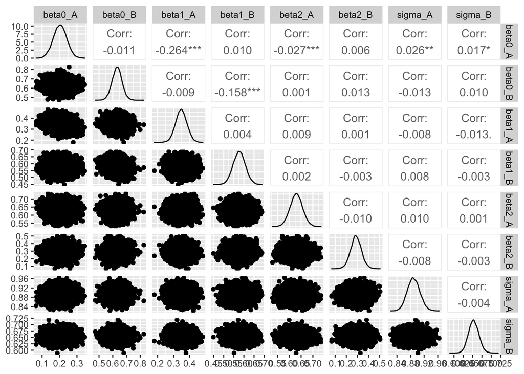

```r
ggpairs(chains_linear)
```

```r
# Censored normal
chains_ordinal = as.data.frame(
  rbind(results_ordinal$mcmc[[1]], results_ordinal$mcmc[[2]], results_ordinal$mcmc[[3]])
)
colnames(chains_ordinal) <- c("beta0_A","beta0_B","beta1_A","beta1_B","beta2_A","beta2_B","sigma_A","sigma_B")
kable(summary(results_ordinal), digits = 3, align = "c")
```

|  | Lower95 | Median | Upper95 | Mean | SD | Mode | MCerr | MC%ofSD | SSeff | AC.10 | psrf |
| --- | --- | --- | --- | --- | --- | --- | --- | --- | --- | --- | --- |
| beta0.mu[1] | 3.888 | 3.961 | 4.037 | 3.960 | 0.038 | NA | 0.001 | 2.3 | 1946 | 0.116 | 1.001 |
| beta0.mu[2] | 3.687 | 3.759 | 3.832 | 3.759 | 0.037 | NA | 0.001 | 1.9 | 2871 | 0.063 | 1.001 |
| xbeta.mu[1,1] | 0.471 | 0.549 | 0.632 | 0.549 | 0.041 | NA | 0.000 | 1.1 | 7572 | 0.003 | 1.000 |
| xbeta.mu[2,1] | 0.993 | 1.075 | 1.159 | 1.075 | 0.043 | NA | 0.001 | 1.9 | 2748 | 0.060 | 1.001 |
| xbeta.mu[1,2] | 1.922 | 2.081 | 2.242 | 2.081 | 0.081 | NA | 0.001 | 1.3 | 6399 | 0.021 | 1.000 |
| xbeta.mu[2,2] | 0.316 | 0.499 | 0.672 | 0.500 | 0.090 | NA | 0.001 | 0.8 | 14002 | 0.010 | 1.000 |
| sigma[1] | 0.165 | 0.196 | 0.229 | 0.196 | 0.016 | NA | 0.000 | 1.4 | 4987 | -0.012 | 1.001 |
| sigma[2] | 0.467 | 0.505 | 0.544 | 0.505 | 0.020 | NA | 0.000 | 1.3 | 5713 | 0.013 | 1.000 |

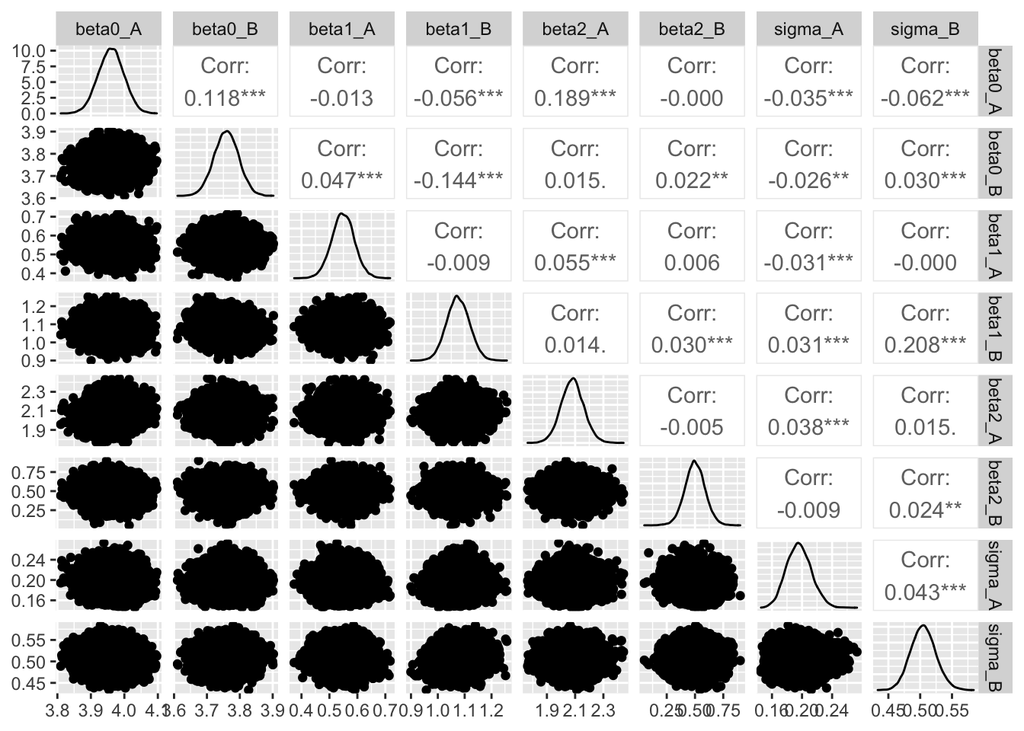

```r
ggpairs(chains_ordinal)
```

### Contrast between x1 and x2

> *Answer:* In both models, Group A’s $\beta_1$ is significantly smaller than $\beta_2$, whereas Group B’s $\beta_1$ is significantly larger than $\beta_2$. However the difference between $\beta_1$ and $\beta_2$ in both groups is estimated more drastically in Ordinal model than in Metric model.

#### Hierarchical linear regression model

**beta1_A – beta2_A**

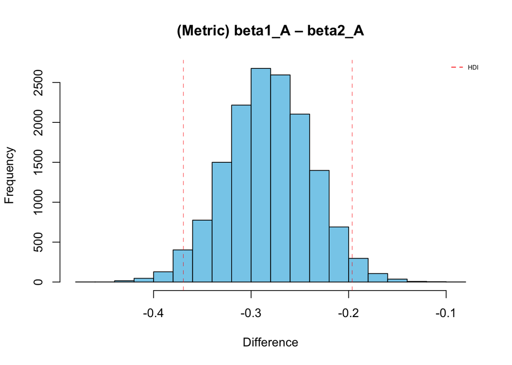

```r
b1_b2_A_lin <- chains_linear$beta1_A - chains_linear$beta2_A
hist(b1_b2_A_lin, main = "(Metric) beta1_A – beta2_A", xlab = "Difference", col = "skyblue")
abline(v = hdi(b1_b2_A_lin), col = "red", lwd = .5, lty = "dashed")
legend("topright", legend = c("HDI"),
       col = c("red"), lty = c("dashed"),
       box.lty=0, cex = 0.5)
```

**beta1_B – beta2_B**

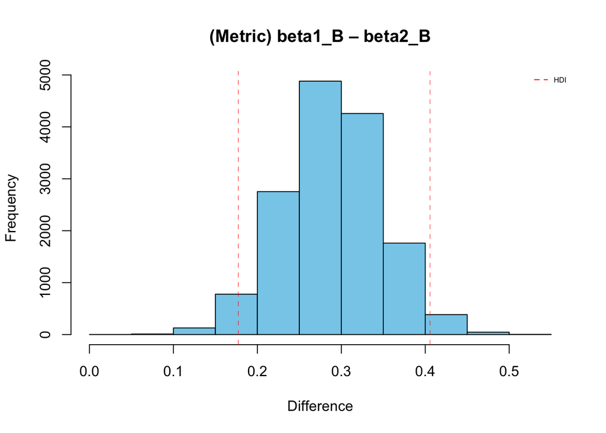

```r
b1_b2_B_lin <- chains_linear$beta1_B - chains_linear$beta2_B
hist(b1_b2_B_lin, main = "(Metric) beta1_B – beta2_B", xlab = "Difference", col = "skyblue")
abline(v = hdi(b1_b2_B_lin), col = "red", lwd = .5, lty = "dashed")
legend("topright", legend = c("HDI"),
       col = c("red"), lty = c("dashed"),
       box.lty=0, cex = 0.5)
```

#### Hierarchical ordinal regression model

**beta1_A – beta2_A**

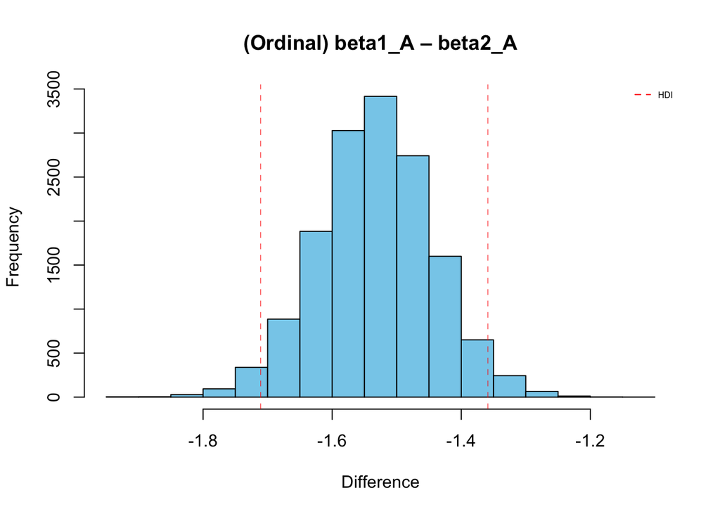

```r
b1_b2_A_ord <- chains_ordinal$beta1_A - chains_ordinal$beta2_A
hist(b1_b2_A_ord, main = "(Ordinal) beta1_A – beta2_A", xlab = "Difference", col = "skyblue")
abline(v = hdi(b1_b2_A_ord), col = "red", lwd = .5, lty = "dashed")
legend("topright", legend = c("HDI"),
       col = c("red"), lty = c("dashed"),
       box.lty=0, cex = 0.5)
```

**beta1_B – beta2_B**

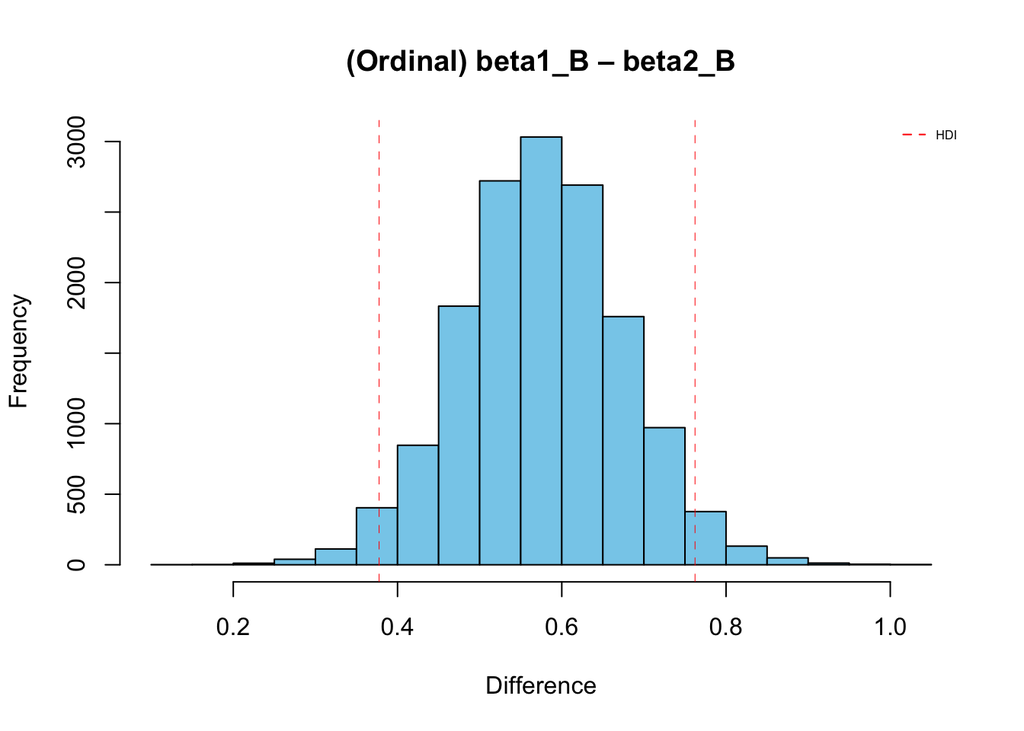

```r
b1_b2_B_ord <- chains_ordinal$beta1_B - chains_ordinal$beta2_B
hist(b1_b2_B_ord, main = "(Ordinal) beta1_B – beta2_B", xlab = "Difference", col = "skyblue")
abline(v = hdi(b1_b2_B_ord), col = "red", lwd = .5, lty = "dashed")
legend("topright", legend = c("HDI"),
       col = c("red"), lty = c("dashed"),
       box.lty=0, cex = 0.5)
```

### Contrast between models

> *Answer:* The $\beta$s differ significantly within groups across two models.

#### Metric beta1_A - Ordinal beta1_A

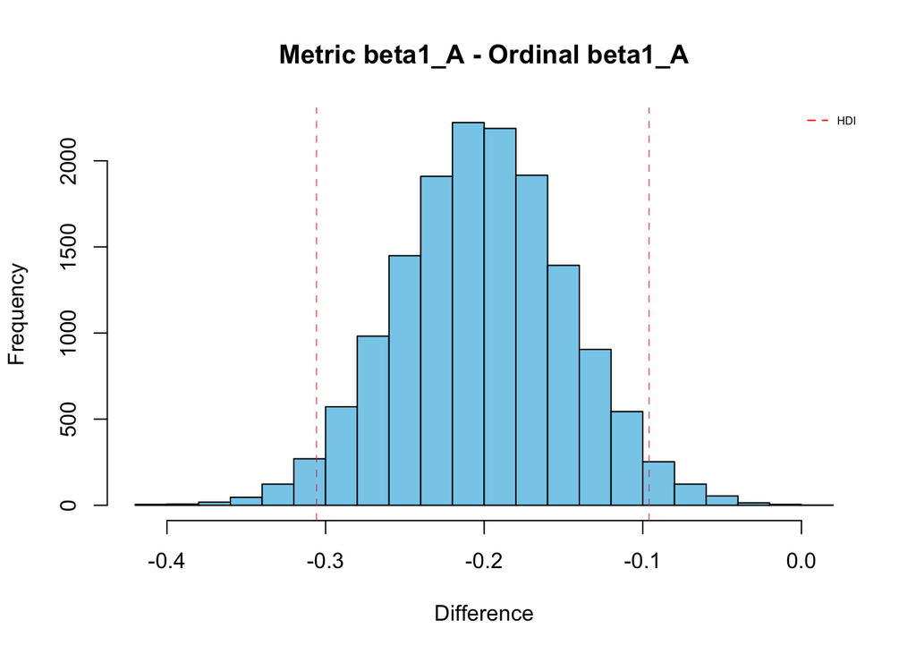

```r
M_O_b1_A <- chains_linear$beta1_A - chains_ordinal$beta1_A
hist(M_O_b1_A, main = "Metric beta1_A - Ordinal beta1_A", xlab = "Difference", col = "skyblue")
abline(v = hdi(M_O_b1_A), col = "red", lwd = .5, lty = "dashed")
legend("topright", legend = c("HDI"),
       col = c("red"), lty = c("dashed"),
       box.lty=0, cex = 0.5)
```

#### Metric beta2_A - Ordinal beta2_A

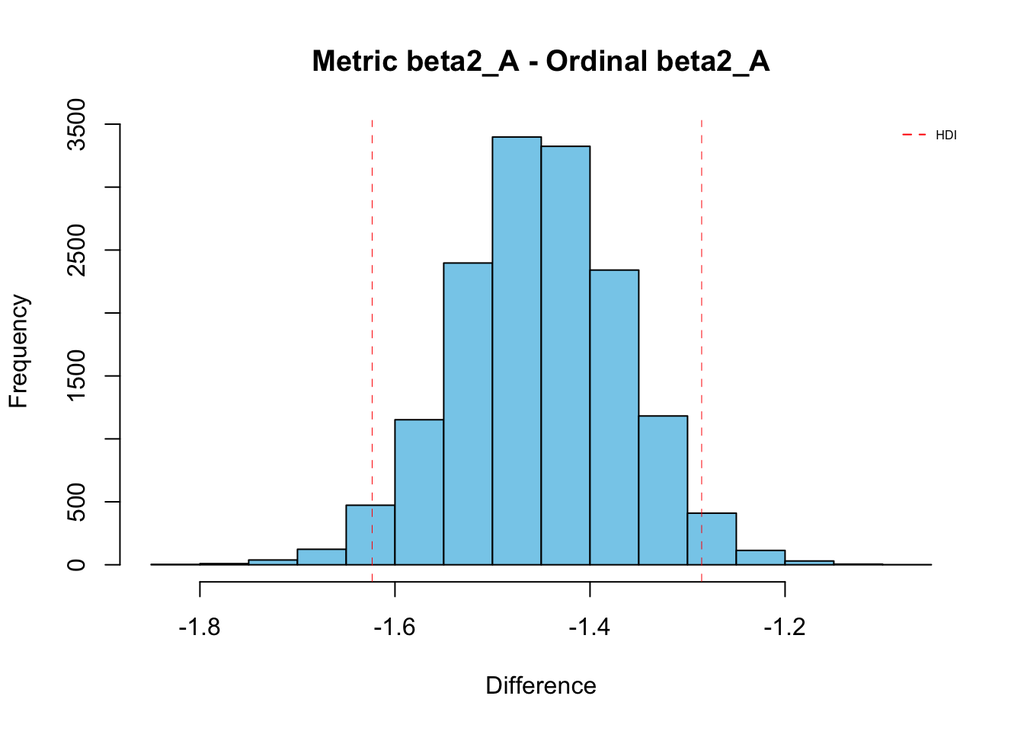

```r
M_O_b2_A <- chains_linear$beta2_A - chains_ordinal$beta2_A
hist(M_O_b2_A, main = "Metric beta2_A - Ordinal beta2_A", xlab = "Difference", col = "skyblue")
abline(v = hdi(M_O_b2_A), col = "red", lwd = .5, lty = "dashed")
legend("topright", legend = c("HDI"),
       col = c("red"), lty = c("dashed"),
       box.lty=0, cex = 0.5)
```

#### Metric beta1_B - Ordinal beta1_B

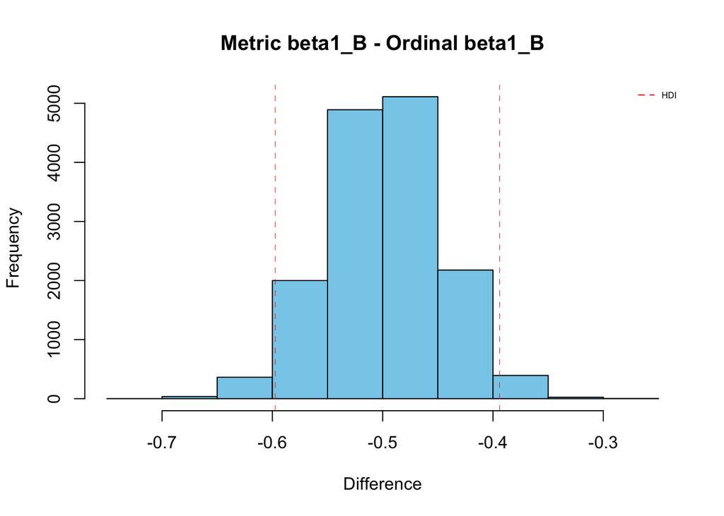

```r
M_O_b1_B <- chains_linear$beta1_B - chains_ordinal$beta1_B
hist(M_O_b1_B, main = "Metric beta1_B - Ordinal beta1_B", xlab = "Difference", col = "skyblue")
abline(v = hdi(M_O_b1_B), col = "red", lwd = .5, lty = "dashed")
legend("topright", legend = c("HDI"),
       col = c("red"), lty = c("dashed"),
       box.lty=0, cex = 0.5)
```

#### Metric beta2_B - Ordinal beta2_B

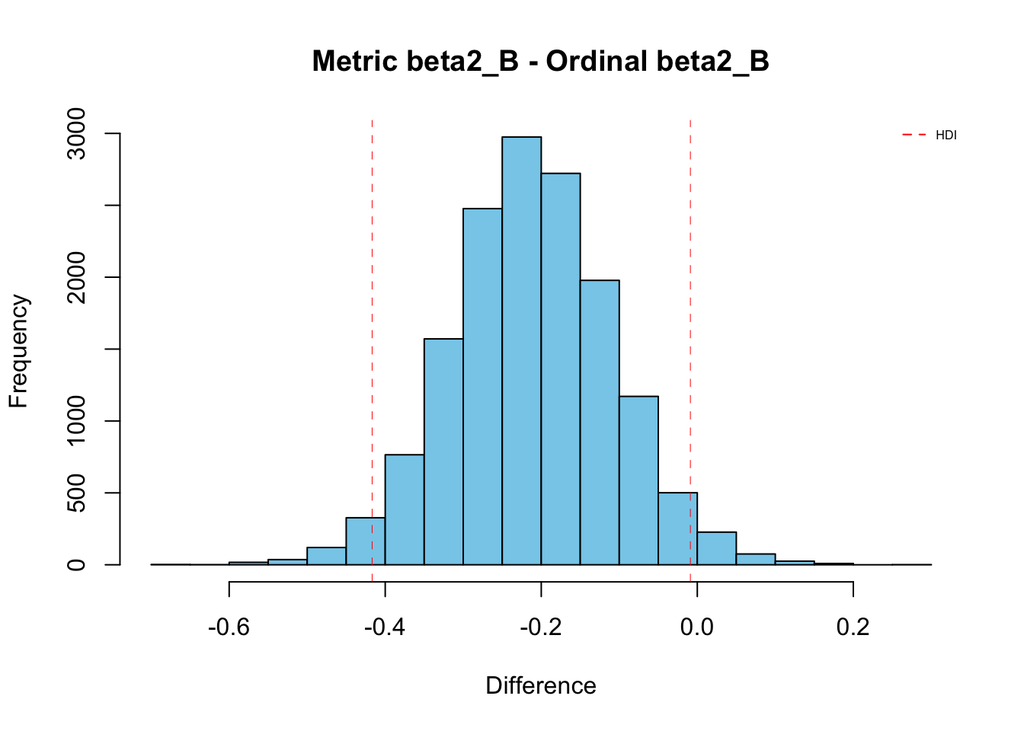

```r
M_O_b2_B <- chains_linear$beta2_B - chains_ordinal$beta2_B
hist(M_O_b2_B, main = "Metric beta2_B - Ordinal beta2_B", xlab = "Difference", col = "skyblue")
abline(v = hdi(M_O_b2_B), col = "red", lwd = .5, lty = "dashed")
legend("topright", legend = c("HDI"),
       col = c("red"), lty = c("dashed"),
       box.lty=0, cex = 0.5)
```

#### Metric x1x2_diff_A - Ordinal x1x2_diff_A

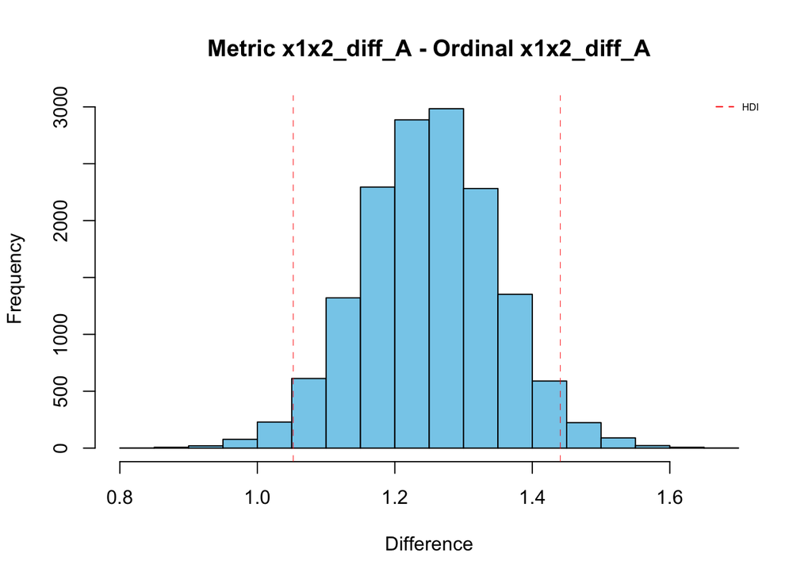

```r
M_O_xdiff_A <- b1_b2_A_lin - b1_b2_A_ord
hist(M_O_xdiff_A, main = "Metric x1x2_diff_A - Ordinal x1x2_diff_A", xlab = "Difference", col = "skyblue")
abline(v = hdi(M_O_xdiff_A), col = "red", lwd = .5, lty = "dashed")
legend("topright", legend = c("HDI"),
       col = c("red"), lty = c("dashed"),
       box.lty=0, cex = 0.5)
```

#### Metric x1x2_diff_B - Ordinal x1x2_diff_B

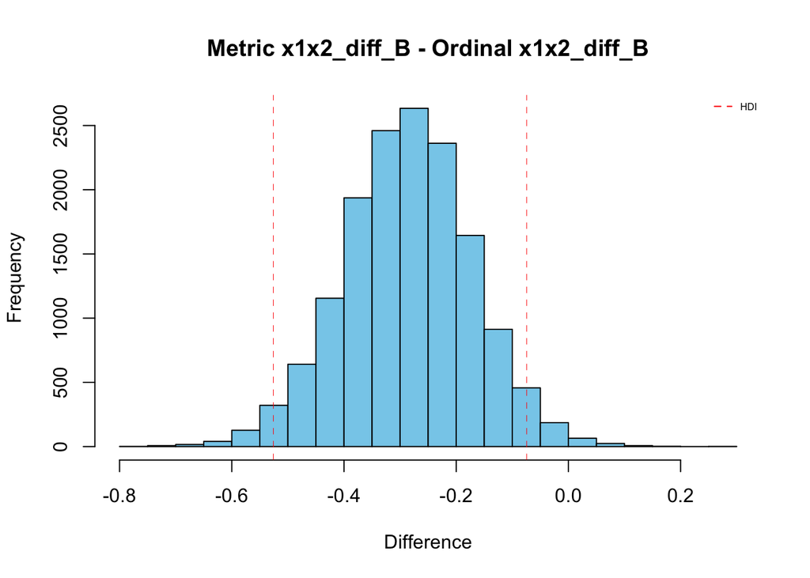

```r
M_O_xdiff_B <- b1_b2_B_lin - b1_b2_B_ord
hist(M_O_xdiff_B, main = "Metric x1x2_diff_B - Ordinal x1x2_diff_B", xlab = "Difference", col = "skyblue")
abline(v = hdi(M_O_xdiff_B), col = "red", lwd = .5, lty = "dashed")
legend("topright", legend = c("HDI"),
       col = c("red"), lty = c("dashed"),
       box.lty=0, cex = 0.5)
```